# Quantitative Spatial Economics

## Tutorial Topic 2: Monocentric City Model

Humboldt University Berlin & Berlin School of Economics

Authors: Dominik Bursy, Lars Felder, Kate Bablyak, Marlon Krippendorf

Last Update: May 2024

In Topic 2,we covered the monocentric city model in the lecture. In this tutorial, we test for the central prediction of the model, i.e. that bid-rents fall in distance from the central business district.

## Directory Structure

Start by cloning the repository AHS2023-toolkit in the ressource directory and copy `_USE_PREDICT.do` to the notebooks directory. lfelder: Note that you need to rename the repo to `AHS2023-toolkit-main` as this is the folder name used in the `_USE_PREDICT.do` file.

```
├── data
│   ├── _README.txt
│   ├── county-employment-2023
│   ├── county-gdp_capita-2021
│   ├── county-wages-2022
│   ├── RWI-GEO-RED-2022
│   └── Shapefiles-2022
├── experiments
├── notebooks
│   ├── _USE_PREDICT.do
│   ├── QSE_Tutorial_1_Group_2.ipynb
│   └── QSE_Tutorial_2_Group_2.ipynb
├── output
├── resources
│   ├── AHS2023-toolkit-main
│   └── Tutorial_Handout_2.pdf
├── requirements.txt
├── README.md
└── LICENSE
```

- Import Packages
- Data Import and Data Preparation
  - Data Import 1: German Cities
  - Data Import 2: Transactions Panel
  - Data Preparation
- Task 1: Create House Price Index
- Task 2: Vizualize House Price Index
- Task 3: Price Gradient from Central Business Districts (CBD)
- Task 4: Conclusion
- Appendix
- References

## Task 2: Vizualize House Price Index

### Real Estate Prices

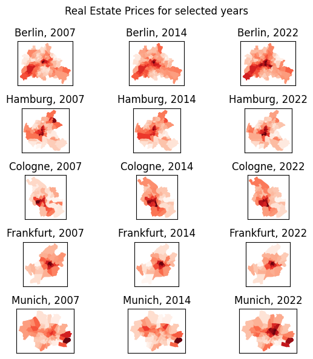

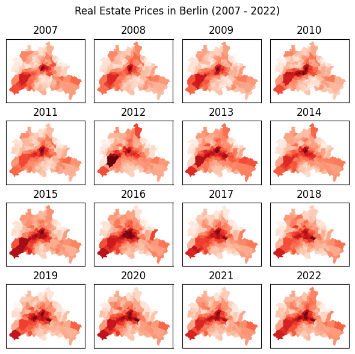

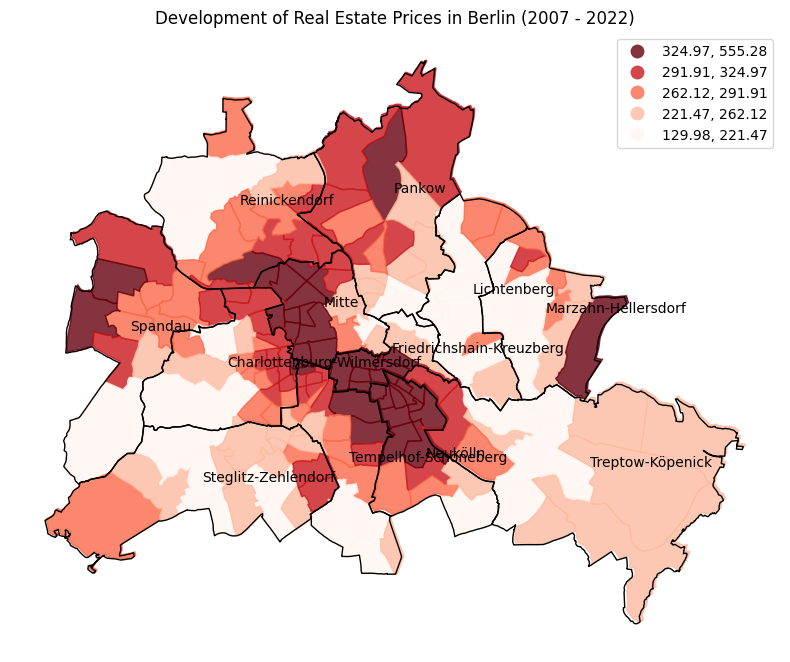

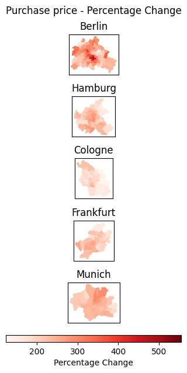

### Rent Prices

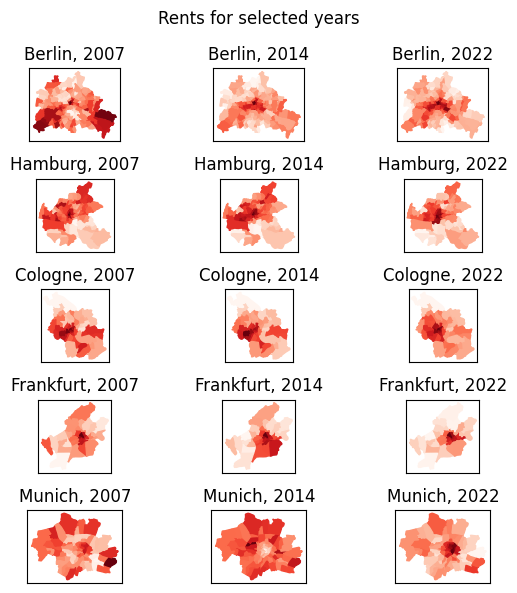

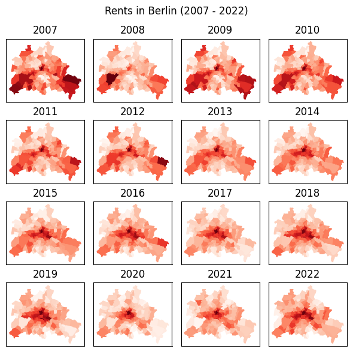

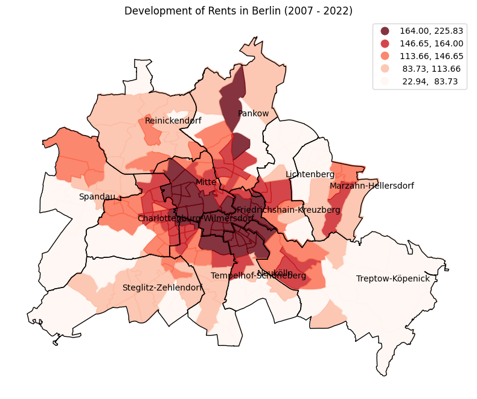

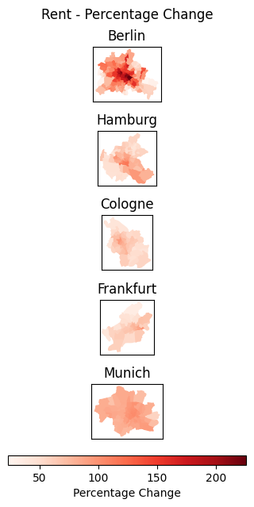

### Interpreation

Does the pattern conform to the monocentric city model?

- The Monocentric City Model would predict High Rents and High Purchase Prices in Central Business Districts (CBD).
- However, in the data for Berlin, we tend to find two areas where prices are high: in the city center and in the area closer to Potsdam.
- This points to one shortcoming of the Monocentric City Model, which ignores factors other than the proximity of workers’ housing location to their central workplace.
- High prices in areas closer to Potsdam are probably driven by their proximity to another major German city, nature, etc.
- Suggestion: instead of analyzing cities as labour markets, take a broader stance and analyze local labour markets, to which people from multiple cities commute

Are there any obvious changes over time?

- In Berlin, the city center expands over time
- In Hamburg, we see the opposite trend: the city center concentrates
- In Cologne, areas to the west of the Rhine river are much more expensive than areas to the east
- In Frankfurt, we don’t observe much change in city center dispersion over time
- In Munich, prices increase in general, but the spatial pattern does not change much

## Task 3: Price Gradient from Central Business Districts (CBD)

Note that the distance measure is the euclidian distance of two ETRS projected coordinates i.e. it is measured in meters. For inerpretation purposes of the regression coefficients it might make sense to multiply by 100 for 100meters as 1meter is a too small change to be of practical relevance.

```
Distance Coefficients (sclaed by 1000) by City in 2007:
Berlin    : -0.0204865874
Hamburg   : -0.0252524629
Munich    : -0.0097987741
Cologne   : -0.0324136596
Frankfurt : -0.0682054967
```

Interpretation of the coefficients above: In 2007: an increase in distance from cbd by 1km in Berlin is associated with a decrease in purchase prices by 2%. This effect is larger for all other cities with the weird exception of Munich (where everything is expensive everywhere, bc. ppl. work in automotive industry?)

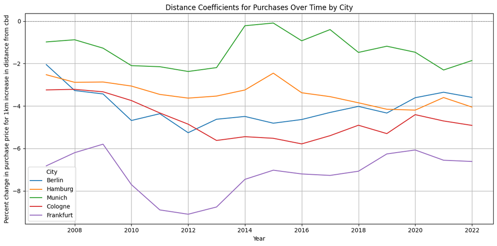

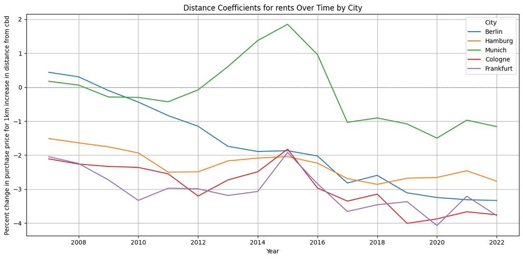

Munich seems very weird! Both for purchases but especially rents. Much clearer overall pattern visible for rents than for purchases (i.e. downwards pattern in line with monocentric city model hypothesis)

```
                            OLS Regression Results
==============================================================================
Dep. Variable:             dlprice_qm   R-squared:                       0.197
Model:                            OLS   Adj. R-squared:                  0.180
Method:                 Least Squares   F-statistic:                     11.35
Date:                Fri, 02 May 2025   Prob (F-statistic):           2.92e-08
Time:                        13:25:32   Log-Likelihood:                 72.726
No. Observations:                 190   AIC:                            -135.5
Df Residuals:                     185   BIC:                            -119.2
Df Model:                           4
Covariance Type:            nonrobust
==============================================================================
                 coef    std err          t      P>|t|      [0.025      0.975]
------------------------------------------------------------------------------
const          1.2490      0.020     62.486      0.000       1.210       1.288
2.0            0.0267      0.036      0.731      0.466      -0.045       0.099
3.0            0.1536      0.033      4.633      0.000       0.088       0.219
4.0            0.1911      0.033      5.811      0.000       0.126       0.256
5.0            0.1228      0.059      2.073      0.040       0.006       0.240
==============================================================================
Omnibus:                        1.446   Durbin-Watson:                   0.695
Prob(Omnibus):                  0.485   Jarque-Bera (JB):                1.091
Skew:                           0.154   Prob(JB):                        0.579
Kurtosis:                       3.206   Cond. No.                         5.46
==============================================================================

Notes:
[1] Standard Errors assume that the covariance matrix of the errors is correctly specified.
```

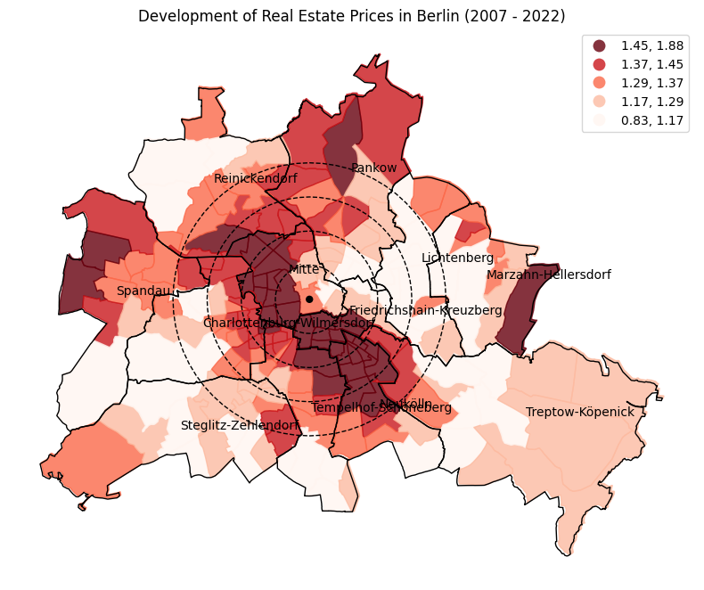

## Task 4: Conclusion

- The model is a good proxy for how high rents and purchase prices tend to concentrate in city centers
- However, the price pattern in many cities is more complex than a single city center in the middle
- Assumption of one Commercial Business District (CBD) in city center often unrealistic in real world
  - High Real Estate prices in Berlin areas close to Potsdam cannot be explained by Monocentric city model
- City center confirms most to pattern observed in cities with a strong service sector (non-industry, e.g. Frankfurt) not requiring much space
  - But then, Home-Office fundamentally changes the pattern: people do not necessarily have to live close to the central workplace at all, workplaces in service sector will most likely decentralize in the future -> assumption of central city center becomes less and less credible
  - Cities with strong industry sector are not centralized to begin with

## Appendix

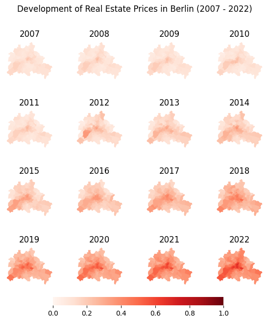

## References

- GitHub AHS2023-toolkit
- https://github.com/Ahlfeldt/AABPL-toolkit-python?tab=readme-ov-file
- ...